# Twitterデータの可視化

山本雅資

2022-07-10

## Mecabのインストール

はじめに日本語の形態素解析に必要なMecabというソフトウェアをインストールする。

### 2. Macの場合

MacがIntelかM1チップかを確認する。M1チップのMacに誤ってIntel版のRがインストールされていないかも確認する。

1. Mecab本体と辞書をダウンロード

http://taku910.github.io/mecab/

2. User/mac/mecab/に保存 (ないフォルダは作る)
3. ターミナルを立ち上げて以下を実行する (Mecab本体のインストール)

https://github.com/IshidaMotohiro/RMeCab/issues/13

cd Users/mac/mecab/

tar xf mecab-0.996.tar.gz

cd mecab-0.996

. /configure –with-charset=utf8

make

sudo make install

以上でMeCabのインストールが終了する。

4. ターミナルから以下を実行する（辞書のインストール）

cd Users/mac/mecab/

tar zvxf mecab-ipadic-2.7.0-20070801.tar.gz

cd mecab-ipadic-2.7.0-20070801

./configure –with-charset=utf8

make

sudo make install

以上でMeCabが使う辞書のインストールが終了する。

以下をターミナルで確認する。

$ mecab

すもももももももものうち

すもも 名詞,一般,*,*,*,*,すもも,スモモ,スモモ

も 助詞,係助詞,*,*,*,*,も,モ,モ

もも 名詞,一般,*,*,*,*,もも,モモ,モモ

も 助詞,係助詞,*,*,*,*,も,モ,モ

もも 名詞,一般,*,*,*,*,もも,モモ,モモ

の 助詞,連体化,*,*,*,*,の,ノ,ノ

## 利用するパッケージ

```r
# install.packages("wordcloud2")

library(ggplot2)
library(rtweet)
library(tidytext)
library(dplyr)
library(RMeCab)
library(wordcloud2)
library(lubridate)
library(tidyr)
library(stringr)


# ディレクトリの設定
# ここで指定したディレクトリにtmp_dataというフォルダを事前に作成する。
setwd("/Users/yamamoto/R/forTeaching/")
```

## Twitterでの検索ワード

以下の$x$に検索したいワードを指定する。 $n$は入手するtweetの数（ただし、無料版では1週間程度しかさかのぼれない）。

```r
#検索ワード
x="行動制限"

# こちらにお世話になりました
#https://medium.com/@afrasyab/the-best-way-to-use-r-to-get-twitter-data-56ad122194f
rt<-search_tweets(x, n=10000,include_rts = FALSE)
```

## ワードクラウド

ワードクラウドでカウントしたくない記号などを排除する。

```r
# 分析に加えたくない記号などを削除する
rt$text <- gsub("https://.*", "", rt$text)
rt$text <- gsub("@", "", rt$text)
rt$text <- gsub("RT", "", rt$text)
rt$text <- gsub("#", "", rt$text)
rt$text <- gsub("\\(", "", rt$text)
rt$text <- gsub("\\)", "", rt$text)
rt$text <- gsub("/", "", rt$text)
rt$text <- gsub(":", "", rt$text)

# こちらにお世話になりました
# https://note.com/text_tier2718/n/n6b20ccd3cb49
rt$text <- rt$text %>%
  str_replace_all(pattern = '\\p{ASCII}',replacement = "") # 記号を消します。
```

形態素解析を実施

```r
rt_text <- rt$text %>%
  na.omit() %>%
  #iconv(from = "UTF-8", to = "CP932") %>%  # windowsのみEncodeの変更が必要です。
  paste(collapse = "")    # テキストを結合
textfile <- tempfile()    # 一時ファイルの入れ物を作成
write(rt_text, textfile) # docDFで読むために一時ファイルを作成

cloud <- docDF(textfile, type = 1) #形態素解析を行う際に特定の品詞に絞って抽出
```

```
## file_name =  /var/folders/13/9dn0stxj0ms73960hn9c5b9r0000gn/T//RtmpstyWKe/file2b79fd20610 opened
## number of extracted terms = 16736
## now making a data frame. wait a while!
```

```r
#cloud <- docDF(textfile, type = 1, pos = "名詞")

unlink(textfile) # 一時ファイル消去
cloud <- cloud %>%
  select(everything(), FREQ = starts_with("file")) %>% # 4列目のfile****....という名前が長いためFREQへ変更
  arrange(desc(FREQ))

# 消したい不要なワードを設定
exclude_word = c("する","なる","やる","ある","いる","-","♪","制限","行動",x)

# 動詞と名詞で良い感じのやつを残す
cloud2 <- cloud %>%
  filter(grepl(pattern = "動詞|名詞", x = POS1) &
           !grepl(pattern = "助動詞|代名詞", x = POS1) &
           !grepl(pattern = "非自立|接尾|数|代名詞", x = POS2)
  ) %>%
  filter(!TERM %in% exclude_word)
```

可視化をする。

```r
# Takaoフォント様 https://launchpad.net/takao-fonts
cloud2 %>%
  select(TERM,FREQ) %>%
  slice(1:100) %>% # 描画する範囲を設定
  wordcloud2(fontFamily = 'Takao Pゴシック', color = "random-light",
             minRotation = 0, maxRotation = 0, size = 1.2)
```

[interactive chart not shown]

## Tweetのネガポジ分析

Tweetテキストに対して感情分析を行います。

感情分析とは(ざっくり言うと)、テキストに含まれている単語がそれぞれネガティブな表現なのかポジティブな表現なのかを評価し、テキスト全体がネガ・ポジどちらなのかを判定するものです。

取得したツイート日時はPOSIXct型の世界共通時(UTC)なので、これをas.POSIXlt()でPOSIXlt型の日本標準時(JST)に変換します。

```r
# ツイート日時の抽出とPOSIXlt型・タイムゾーンの変換
tw_time <- rt[["created_at"]] %>%
  as.POSIXct(tz = "Etc/GMT") %>%
  as.POSIXlt(tz = "Japan")

# ツイートテキストの抽出と文字列処理
tw_text <- rt[["text"]] %>%
  str_remove_all("^@.*?\\s") %>% # リプライ先の除去
  str_remove_all(("https?://[\\w/:%#\\$&\\?\\(\\)~\\.=\\+\\-]+")) %>% # urlの除去
  str_remove_all("[\U0001F004-\U000207BF]")  # 絵文字の除去
```

ここの$term$というワードを変更することで集計する期間を変更できる。

```r
# 単位(期間)を指定
term <- "mon"
term <- "day"

# 期間ごとにツイートテキストをまとめる
text_df <- data.frame(
  terms = as.Date(floor_date(tw_time, term)), # 指定した期間で丸める
  texts = tw_text) %>%
  group_by(terms) %>% # 期間ごとにグループ化
  summarise(texts = paste(texts, collapse = "\n")) # 同一期間のテキストを結合
```

`floor_date()'で指定した期間(単位)に丸めて、`as_date()’にDate型の日付データに変換します(時刻データを落とします)。

```r
# 単語感情極性対応表の取得
np_dic_original <- read.csv(file('http://www.lr.pi.titech.ac.jp/~takamura/pubs/pn_ja.dic',
                                 encoding='Shift_JIS'), header = F, sep = ":")


# ネガポジ辞書の作成
np_dic <- np_dic_original %>%
  select(TERM = V1, POS1 = V3, allocation = V4) %>% # 列の選択
  distinct(TERM, .keep_all = TRUE) # 重複の除去

head(np_dic)
```

```
##       TERM   POS1 allocation
## 1   優れる   動詞   1.000000
## 2     良い 形容詞   0.999995
## 3     喜ぶ   動詞   0.999979
## 4   褒める   動詞   0.999979
## 5 めでたい 形容詞   0.999645
## 6     賢い 形容詞   0.999486
```

形態素解析を実施し、各単語の配点と出現回数をかけてスコアを計算する。スコアがマイナスなら「ネガティブ」、プラスなら「ポジティブ」、0(またはNA)なら「ニュートラル」のラベルを付与します。

```r
# 一時テキストファイルの保存先を指定
folder_name <- "tmp_data"

# 分析結果の受け皿を初期化
score_df <- data.frame()
for(i in 1:nrow(text_df)) {

  # 一時ファイルパスを作成
  tmp_file_name <- paste("screen_name", "_", text_df[["terms"]][i], ".txt", sep = "")
  tmp_path <- paste(folder_name, tmp_file_name, sep = "/")

  # テキストファイルを書き出し
  write(text_df[["texts"]][i], tmp_path)

  # MeCabによる形態素解析
  mecab_df <- docDF(tmp_path, type = 1, pos = c("動詞", "形容詞", "副詞", "助動詞"))

    if(!is.null(mecab_df)) { ## (NULLでないときのみ)

    # ネガポジ配点を結合
    tmp_score_df <- mecab_df %>%
      left_join(np_dic, by = c("TERM", "POS1")) %>% # 各単語に配点を付与
      mutate(allocation = replace_na(allocation, 0)) %>% # NAを0に置換
      select(TERM, FREQ = tmp_file_name, allocation) # docDF仕様の列名に変更

    # ネガポジスコアを計算
    tmp_score_df <- tmp_score_df %>%
      mutate(terms = text_df[["terms"]][i]) %>% # 日付情報列の追加
      mutate(allocation = replace_na(allocation, 0)) %>% # 配点がNAの場合0に置換
      mutate(score = allocation * FREQ) %>% # (スコア) = (配点) * (語数)
      mutate(
        np_label = case_when(
          score < 0 ~ "negative", # (スコア) < 0ならネガ
          score > 0 ~ "positive", # (スコア) > 0ならポジ
          score == 0 ~ "neutral"  # (スコア) = 0ならニュート
        )
      ) # ネガポジラベルを付与

    # 全期間の結果を結合
    score_df <- rbind(score_df, tmp_score_df)
  }
}
```

```
## file_name =  tmp_data/screen_name_2022-07-02.txt opened
## number of extracted terms = 747
## now making a data frame. wait a while!
```

```
## Note: Using an external vector in selections is ambiguous.
## ℹ Use `all_of(tmp_file_name)` instead of `tmp_file_name` to silence this message.
## ℹ See <https://tidyselect.r-lib.org/reference/faq-external-vector.html>.
```

[output not shown]

```r
tail(score_df)
```

```
##         TERM FREQ allocation      terms     score np_label
## 10567   騙す    2  -0.965659 2022-07-11 -1.931318 negative
## 10568   驚く    1   0.000000 2022-07-11  0.000000  neutral
## 10569   高々    1   0.000000 2022-07-11  0.000000  neutral
## 10570   高い   40   0.000000 2022-07-11  0.000000  neutral
## 10571 高まる    1  -0.199283 2022-07-11 -0.199283 negative
## 10572   黙る    5  -0.829653 2022-07-11 -4.148265 negative
```

単語ごとに得点を与えられたので、次は期間ごとに合計します。

```r
# 期間ごとにネガスコア・ポジスコアの合計
result_df <- score_df %>%
  select(terms, np_label, score, FREQ) %>%
  group_by(terms, np_label) %>%
  summarise(score = sum(score), FREQ = sum(FREQ)) # スコアと頻度を合算
```

可視化

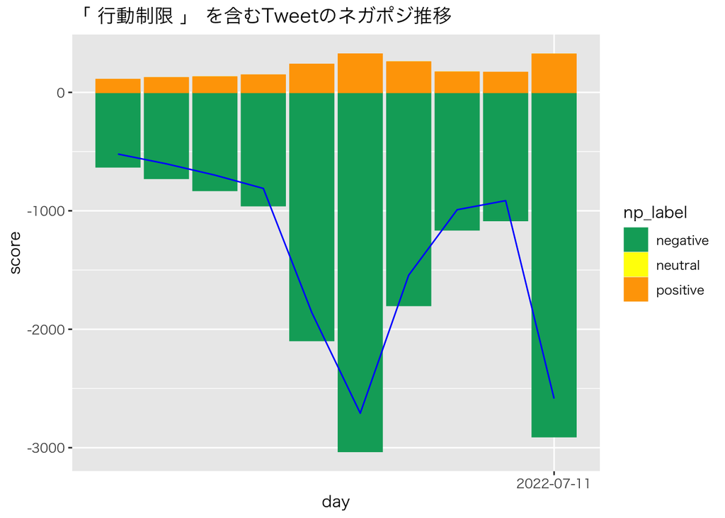

```r
# ggplotを使った可視化
ggplot(result_df, aes(x = terms, y = score)) +
  geom_bar(mapping = aes(fill = np_label, color = np_label), stat = "identity") + # 棒グラフ
  scale_fill_manual(values = c("#00A968", "yellow", "orange")) + # 塗りつぶしの色
  scale_color_manual(values = c("#00A968", "yellow", "orange")) + # 枠の色
  geom_line(stat = "summary", fun = "sum", color = "blue") + # 折れ線グラフ
  scale_x_date(date_breaks = "2 weeks") + # x軸目盛(day)
  #scale_x_date(date_breaks = "1 month", date_labels = "%Y-%m") + # x軸目盛(mon)
  theme(axis.text.x = element_text(angle = 90)) + # x軸目盛の傾き
  theme_gray(base_family = "HiraKakuPro-W3")+
  labs(title = paste("「",x,"」", "を含むTweetのネガポジ推移",seq=""),
       x = term) # ラベル
```